# 上市公司基本情况

- 使用tushare免费的基础信息数据集。(很遗憾,就在2023年5月底这几天,不免费了)
- 2024年7月底，使用akshare的工具从em和cninfo获取数据。
- 数据获取工具放在mytools中。在本文件夹中只拷贝了下载好的数据。
  - em_data.csv
  - cninfo_data.csv

## 数据集的基本情况

### em基本情况

[output not shown]

|  | 列名 | 类型 | 缺失比% | 样例 |
| --- | --- | --- | --- | --- |
| 0 | symbol | object | 0.000000 | 300820 |
| 1 | 上市时间 | object | 0.088936 | 20200213 |
| 2 | 总市值 | float64 | 4.500178 | 8381123150.009999 |
| 3 | 总股本 | object | 4.446816 | 220730133.0 |
| 4 | 流通市值 | object | 4.517965 | 4181290231.27 |
| 5 | 流通股 | object | 4.517965 | 110120891.0 |
| 6 | 股票代码 | object | 0.000000 | 300820 |
| 7 | 股票简称 | object | 0.000000 | 英杰电气 |
| 8 | 行业 | object | 4.589114 | 电源设备 |

这个数据是更新至下载当天的情况：

- 股票代码中包括了已经退市的股票，特征是总股本为‘-’。
- 包括待上市的股票，特征旧总市值为’-‘。
- 总市值是下载当天的数据，可以用来做一些基本分析。

### cninfo基本情况

|  | 列名 | 类型 | 缺失比% | 样例 |
| --- | --- | --- | --- | --- |
| 0 | 公司名称 | object | 0.000000 | 深圳市深科达智能装备股份有限公司 |
| 1 | 英文名称 | object | 0.000000 | Shenzhen S-king Intelligent Equipment Co., Ltd. |
| 2 | 曾用简称 | object | 74.319284 | NaN |
| 3 | A股代码 | float64 | 0.018650 | 688328.0 |
| 4 | A股简称 | object | 0.018650 | 深科达 |
| 5 | B股代码 | float64 | 98.619918 | NaN |
| 6 | B股简称 | object | 98.619918 | NaN |
| 7 | H股代码 | float64 | 97.239836 | NaN |
| 8 | H股简称 | object | 97.239836 | NaN |
| 9 | 入选指数 | object | 14.994405 | 国证Ａ指 |
| 10 | 所属市场 | object | 0.000000 | 上交所科创板 |
| 11 | 所属行业 | object | 0.018650 | 专用设备制造业 |
| 12 | 法人代表 | object | 0.000000 | 黄奕宏 |
| 13 | 注册资金 | float64 | 0.055949 | 9445.6295 |
| 14 | 成立日期 | datetime64[ns] | 0.000000 | 2004-06-14 00:00:00 |
| 15 | 上市日期 | datetime64[ns] | 0.093249 | 2021-03-09 00:00:00 |
| 16 | 官方网站 | object | 0.484894 | www.szskd.com |
| 17 | 电子邮箱 | object | 0.018650 | irm@szskd.com |
| 18 | 联系电话 | object | 0.000000 | 0755-27889869 |
| 19 | 传真 | object | 0.484894 | 0755-27889996 |
| 20 | 注册地址 | object | 0.000000 | 广东省深圳市宝安区福永街道征程二路2号A栋、B栋第一至三层、C栋第一层、D栋 |
| 21 | 办公地址 | object | 0.000000 | 广东省深圳市宝安区福永街道征程二路2号A栋、B栋第一至三层、C栋第一层、D栋 |
| 22 | 邮政编码 | object | 0.018650 | 518103 |
| 23 | 主营业务 | object | 0.000000 | 平板显示器件生产设备的研发、生产和销售。 |
| 24 | 经营范围 | object | 0.111899 | 一般经营项目：智能信息终端嵌入式软件及系统整体解决方案、自动化制造工艺系统研发及系统集成、客... |
| 25 | 机构简介 | object | 3.487505 | 发行人由深圳市深科达气动设备有限公司以整体变更方式设立。2014年5月12日，大华出具了《审... |
| 26 | symbol | object | 0.000000 | 688328 |
| 27 | cname | object | 0.000000 | 深科达 |

cninfo可以分析的点

- 分市场的上市公司数量。
- 成立时期到上市日期的时间跨度。
- 分行业上市公司数量。
- 主营业务和经营范围包含某个关键词的公司数量。

## 上市和退市

- 至数据更新时,A股三市现存上市公司5372家。
- 退市250家，但由于没有退市日期，无法分年度分析。

上市数量

5372

退市数量

250

## 每年新增上市公司

- 上市公司，分板块，分市场，分行业情况.

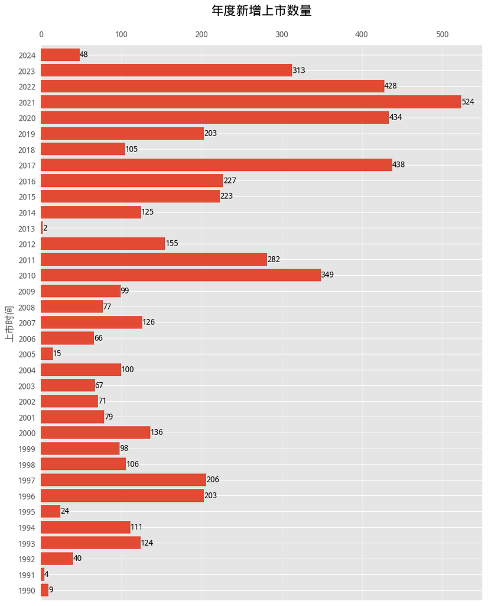

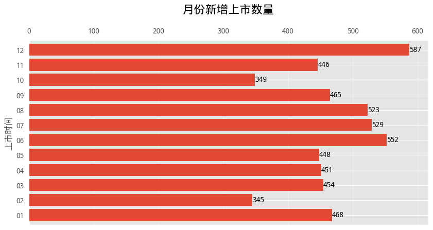

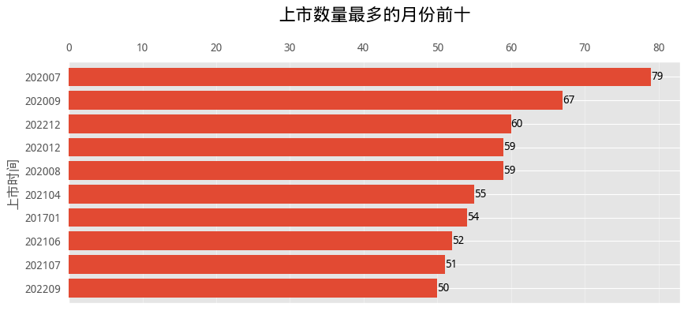

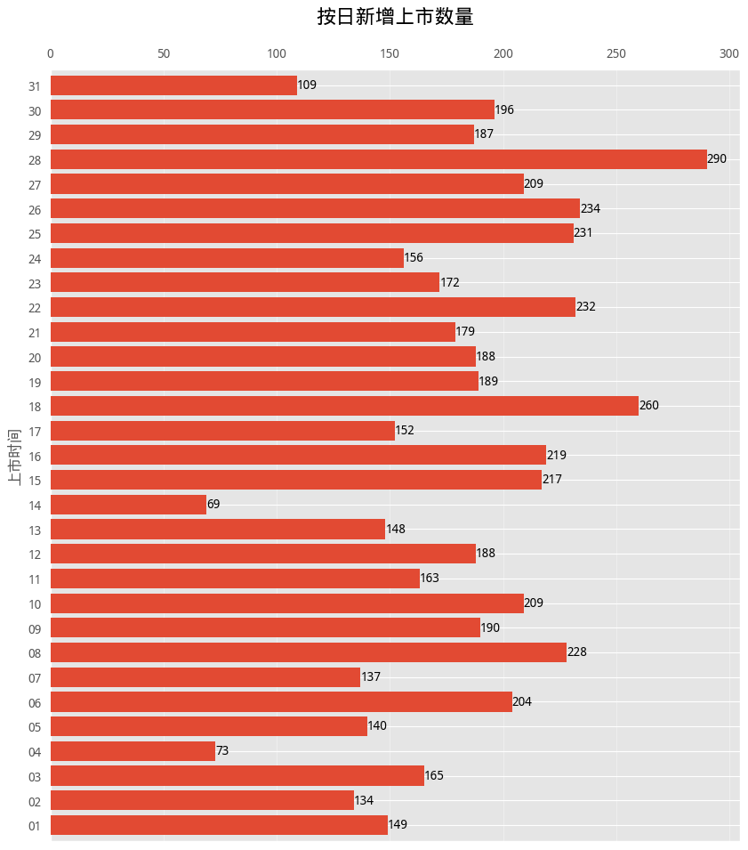

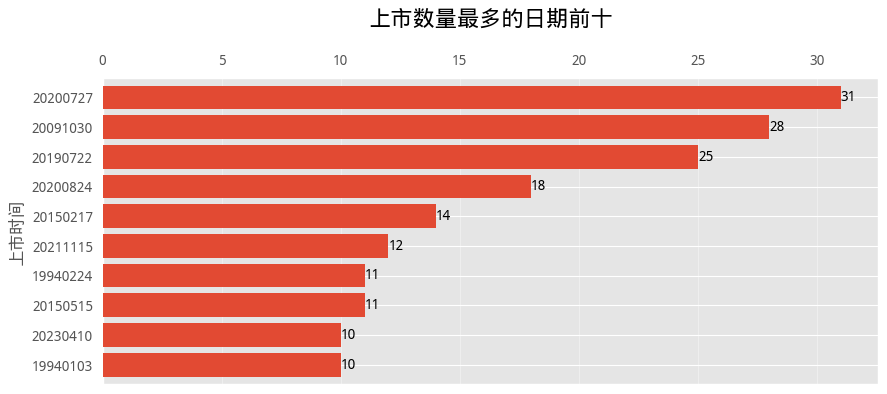

## 交易所和板块

- 三个交易所,四个板块
- 从交易所上市数量来看，深交所规模最大，北交所成立较晚规模最小
- 主板规模最大

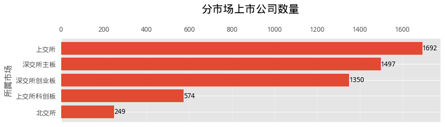

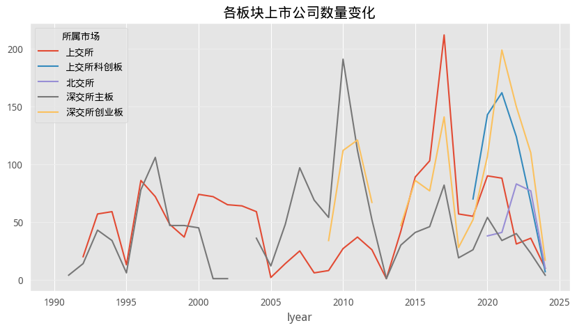

- 北交所没有区分板块
- 上交所交易主板和科创板
- 深交所交易主板和创业板

## 分行业

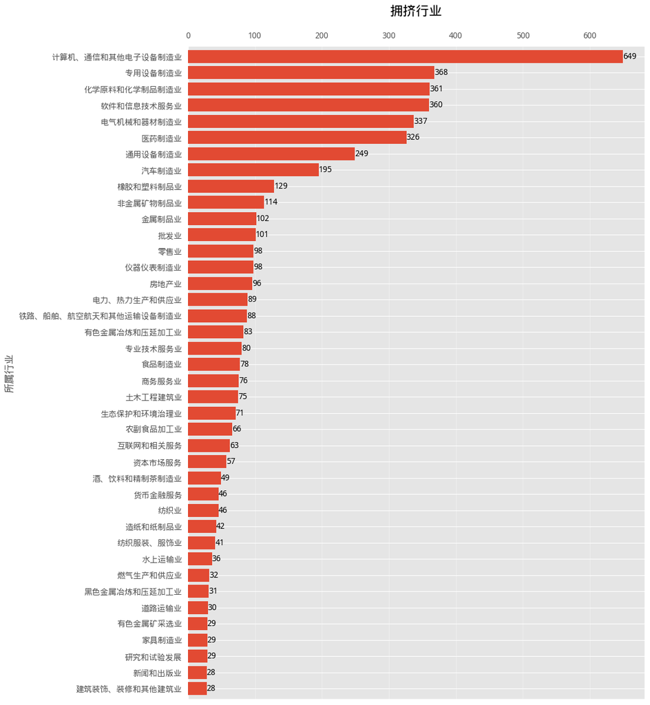

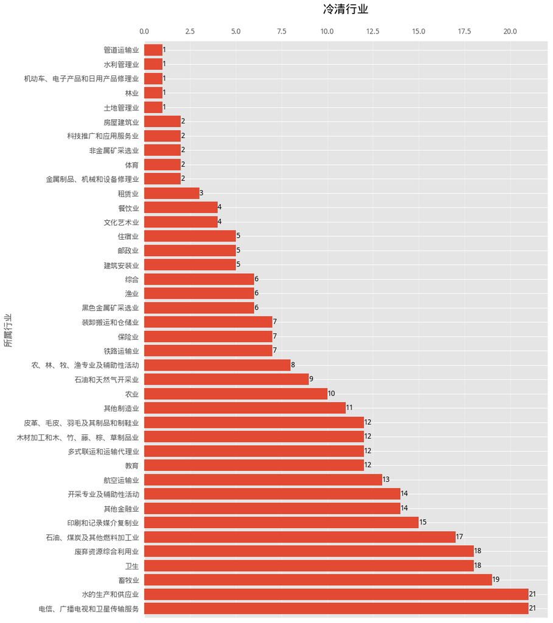

## 分省市情况

- 广东省一枝独秀，主要是包括了深圳。
- 江、浙旗鼓相当。
- 上、北相差不大。
- 山东独占一档。
- 四川在内陆省份中排了第一。

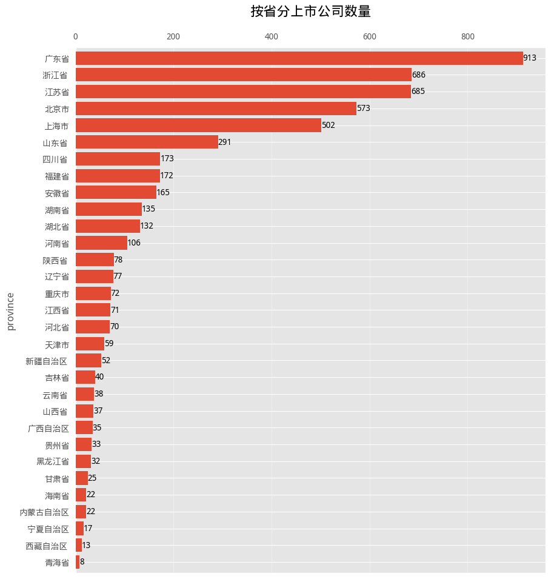

## 按关键词搜索

通过搜索关键词找出在名字、行业、经营范围、主营业务中包含关键词的公司。

- 输入：关键词，显示条数。
- 结果按总市值排序，数值是获得数据集当天的数。
- 搜索数据比较多，所以默认显示前20条。
- 关键字可能是正则式。
- 搜索结果中总市值为空的是未上市的公司。

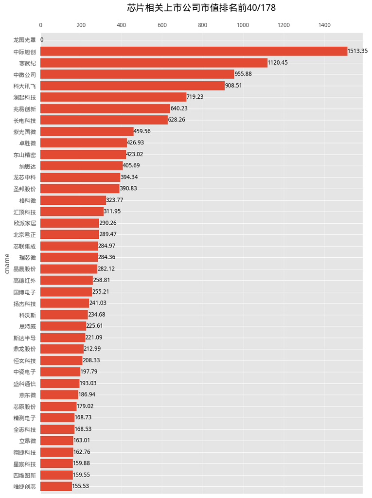

150家银行相关上市公司

| symbol | cname | 总市值 | id | symbol | cname | 总市值 | id | symbol | cname | 总市值 |
| --- | --- | --- | --- | --- | --- | --- | --- | --- | --- | --- |
| 601398 | 工商银行 | 21063.61 | 0 | 601939 | 建设银行 | 18875.83 | 1 | 601288 | 农业银行 | 16484.20 |
| 601988 | 中国银行 | 13747.91 | 0 | 600036 | 招商银行 | 8637.80 | 1 | 601318 | 中国平安 | 7835.86 |
| 601328 | 交通银行 | 5540.00 | 0 | 601658 | 邮储银行 | 4938.22 | 1 | 601166 | 兴业银行 | 3558.64 |
| 601998 | 中信银行 | 3442.60 | 0 | 600030 | 中信证券 | 2873.70 | 1 | 601601 | 中国太保 | 2857.24 |
| 600000 | 浦发银行 | 2562.45 | 0 | 601319 | 中国人保 | 2401.36 | 1 | 000001 | 平安银行 | 2012.39 |
| 601818 | 光大银行 | 1991.18 | 0 | 600016 | 民生银行 | 1659.35 | 1 | 601066 | 中信建投 | 1524.19 |
| 002142 | 宁波银行 | 1473.92 | 0 | 600919 | 江苏银行 | 1440.58 | 1 | 601995 | 中金公司 | 1391.22 |
| 600999 | 招商证券 | 1278.39 | 0 | 601211 | 国泰君安 | 1250.97 | 1 | 601600 | 中国铝业 | 1245.70 |
| 601169 | 北京银行 | 1190.35 | 0 | 601688 | 华泰证券 | 1162.98 | 1 | 601229 | 上海银行 | 1064.08 |
| 601009 | 南京银行 | 1049.90 | 0 | 600015 | 华夏银行 | 1036.06 | 1 | 601336 | 新华保险 | 977.98 |
| 002736 | 国信证券 | 794.95 | 0 | 601916 | 浙商银行 | 788.24 | 1 | 600926 | 杭州银行 | 768.57 |
| 000617 | 中油资本 | 682.67 | 0 | 601018 | 宁波港 | 680.90 | 1 | 601788 | 光大证券 | 679.63 |
| 600958 | 东方证券 | 672.08 | 0 | 688347 | 华虹公司 | 668.90 | 1 | 601825 | 沪农商行 | 657.75 |
| 601901 | 方正证券 | 628.11 | 0 | 600236 | 桂冠电力 | 603.00 | 1 | 601077 | 渝农商行 | 590.56 |
| 601838 | 成都银行 | 569.42 | 0 | 601377 | 兴业证券 | 449.07 | 1 | 601878 | 浙商证券 | 422.77 |
| 600988 | 赤峰黄金 | 337.44 | 0 | 600570 | 恒生电子 | 331.29 | 1 | 601577 | 长沙银行 | 309.26 |
| 601555 | 东吴证券 | 298.12 | 0 | 600483 | 福能股份 | 296.09 | 1 | 601990 | 南京证券 | 279.43 |
| 002673 | 西部证券 | 277.11 | 0 | 002945 | 华林证券 | 274.32 | 1 | 002966 | 苏州银行 | 263.64 |
| 600329 | 达仁堂 | 263.24 | 0 | 601198 | 东兴证券 | 262.15 | 1 | 601963 | 重庆银行 | 256.77 |
| 600816 | 建元信托 | 254.97 | 0 | 601696 | 中银证券 | 247.52 | 1 | 600369 | 西南证券 | 243.88 |
| 601128 | 常熟银行 | 228.23 | 0 | 600901 | 江苏金租 | 223.74 | 1 | 601665 | 齐鲁银行 | 220.96 |
| 002797 | 第一创业 | 210.12 | 0 | 600737 | 中粮糖业 | 196.77 | 1 | 002738 | 中矿资源 | 196.61 |
| 002948 | 青岛银行 | 193.82 | 0 | 601997 | 贵阳银行 | 193.78 | 1 | 002423 | 中粮资本 | 175.57 |
| 002670 | 国盛金控 | 170.09 | 0 | 600325 | 华发股份 | 168.98 | 1 | 002926 | 华西证券 | 168.79 |
| 002500 | 山西证券 | 166.21 | 0 | 300002 | 神州泰岳 | 162.97 | 1 | 002936 | 郑州银行 | 160.02 |
| 002958 | 青农商行 | 147.22 | 0 | 600928 | 西安银行 | 144.44 | 1 | 603613 | 国联股份 | 143.17 |
| 000875 | 吉电股份 | 143.14 | 0 | 000563 | 陕国投Ａ | 141.66 | 1 | 601187 | 厦门银行 | 139.35 |
| 001227 | 兰州银行 | 131.00 | 0 | 000966 | 长源电力 | 119.05 | 1 | 600776 | 东方通信 | 115.30 |
| 600246 | 万通发展 | 113.88 | 0 | 600908 | 无锡银行 | 113.25 | 1 | 000156 | 华数传媒 | 112.10 |
| 002701 | 奥瑞金 | 106.02 | 0 | 000488 | 晨鸣纸业 | 101.12 | 1 | 300773 | 拉卡拉 | 97.28 |
| 601528 | 瑞丰银行 | 95.56 | 0 | 605599 | 菜百股份 | 94.34 | 1 | 002807 | 江阴银行 | 93.29 |
| 601860 | 紫金银行 | 91.89 | 0 | 600508 | 上海能源 | 88.82 | 1 | 603323 | 苏农银行 | 88.36 |
| 300130 | 新国都 | 87.57 | 0 | 600259 | 广晟有色 | 87.51 | 1 | 600446 | 金证股份 | 87.34 |
| 002839 | 张家港行 | 86.35 | 0 | 000048 | 京基智农 | 74.65 | 1 | 301153 | 中科江南 | 72.22 |
| 600882 | 妙可蓝多 | 70.82 | 0 | 600058 | 五矿发展 | 68.17 | 1 | 603383 | 顶点软件 | 65.95 |
| 600603 | 广汇物流 | 63.37 | 0 | 002537 | 海联金汇 | 59.05 | 1 | 002987 | 京北方 | 58.82 |
| 600368 | 五洲交通 | 56.98 | 0 | 000900 | 现代投资 | 55.70 | 1 | 300010 | 豆神教育 | 53.73 |
| 000016 | 深康佳Ａ | 50.57 | 0 | 300872 | 天阳科技 | 49.06 | 1 | 600182 | S佳通 | 45.97 |
| 002017 | 东信和平 | 45.62 | 0 | 600571 | 信雅达 | 45.23 | 1 | 300663 | 科蓝软件 | 44.23 |
| 600479 | 千金药业 | 42.70 | 0 | 001298 | 好上好 | 41.20 | 1 | 600238 | 海南椰岛 | 39.58 |
| 002783 | 凯龙股份 | 35.69 | 0 | 002104 | 恒宝股份 | 35.41 | 1 | 300895 | 铜牛信息 | 35.13 |
| 002300 | 太阳电缆 | 34.89 | 0 | 605218 | 伟时电子 | 34.48 | 1 | 300541 | 先进数通 | 33.67 |
| 002453 | 华软科技 | 32.98 | 0 | 002448 | 中原内配 | 32.54 | 1 | 300805 | 电声股份 | 30.98 |
| 600239 | 云南城投 | 30.51 | 0 | 688590 | 新致软件 | 30.09 | 1 | 300465 | 高伟达 | 29.49 |
| 688793 | 倍轻松 | 28.32 | 0 | 300561 | 汇金科技 | 26.22 | 1 | 600280 | 中央商场 | 25.39 |
| 002177 | 御银股份 | 23.06 | 0 | 688109 | 品茗科技 | 22.51 | 1 | 001219 | 青岛食品 | 21.43 |
| 300380 | 安硕信息 | 20.78 | 0 | 603106 | 恒银科技 | 20.66 | 1 | 600303 | ST曙光 | 17.30 |
| 300419 | 浩丰科技 | 15.96 | 0 | 300333 | 兆日科技 | 14.75 | 1 | 300518 | 新迅达 | 14.16 |
| 600561 | 江西长运 | 13.00 | 0 | 002622 | 皓宸医疗 | 10.00 | 1 | 837592 | 华信永道 | 9.94 |
| 300096 | ST易联 | 9.55 | 0 | 831832 | 科达自控 | 9.15 | 1 | 002325 | *ST洪 | 6.67 |